Analysis file available for download here: https://github.com/ljcohen/ljcohen.github.io/tree/master/analyses/Blanco/

Script associated with this report can be accessed here: https://github.com/ljcohen/ljcohen.github.io/tree/master/analyses/Blanco/scripts/Blanco_RNAseq_report_invivo.Rmd

# Introduction

These data are from two RNASeq transcript experiments combined in one high-output 2 x 50 Illumina HiSeq sequencing run, Blanco_HSQ_1 on May 28, 2014 at the Genome Technology Center, NYU Langone Medical Center. Four lanes of sequences were collected per sample for an average of 75 million reads per sample. In the in vivo experiment, RNA was extracted from aortic tissue from five mouse replicates from the following three groups: 1.) wildtype (WT), 2.) ApoE knockout (ApoE), and 3.) “double-knockout” with both alleles for ApoE and TWEAK knocked down (DKO). In the in vitro cell culture experiment, there were two groups with four samples each: 1.) Basal and 2.) TWEAK 100 administered to the cells.

Basespace link: https://basespace.illumina.com/s/nhKGfWNebV5Q

# Table of Contents:

1. Data Analysis Procedure
2. PCA
3. MA plots
4. Venn Diagram
5. Heatmap
6. Comments
7. Contact
8. References

# 1. Data analysis procedure

The alignment program, Bowtie (version 1.0.0) was used with reads mapped to the UCSC mm9 gff (iGenome version) with two mismatches allowed. The uniquely-mapped reads were subjected to subsequent necessary processing, including removal of PCR duplicates, before transcripts were counted with htseq-count. Counts files were imported into the R statistical programming environment and analyzed with the DESeq2 R/Bioconductor package (Love et al. 2014).

Here, data analysis is presented from the in vivo experiment. Data analysis for the in vitro experiment can be accessed here:

http://ljcohen.github.io/analyses/Blanco/Blanco_RNAseq_report_invitro.html

Filenames containing raw transcript counts from htseq-count are as follows:

```
##  [1] "ApoE-2_counts.txt" "ApoE-3_counts.txt" "ApoE-4_counts.txt"
##  [4] "ApoE-5_counts.txt" "ApoE-6_counts.txt" "DKO-1_counts.txt"
##  [7] "DKO-3_counts.txt"  "DKO-5_counts.txt"  "DKO-6_counts.txt"
## [10] "DKO-7_counts.txt"  "WT-1_counts.txt"   "WT-2_counts.txt"
## [13] "WT-3_counts.txt"   "WT-5_counts.txt"   "WT-6_counts.txt"
```

# 2. PCA

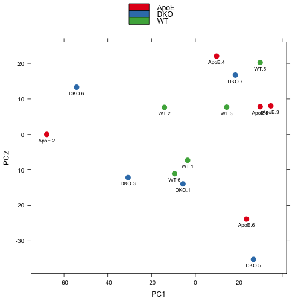

# 3. MA plots

### ApoE vs. WT

The size of the table with all transcripts is:

```
## [1] 16873    22
```

The size of the table with only significant transcripts ApoE vs. WT (padj<0.25) is:

```
## [1] 1267   22
```

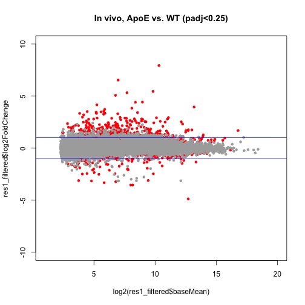

### DKO vs. WT

The size of the table with all transcripts is:

```
## [1] 16873    22
```

The size of the table with only significant transcripts DKO vs. WT (padj<0.25) is:

```
## [1] 1116   22
```

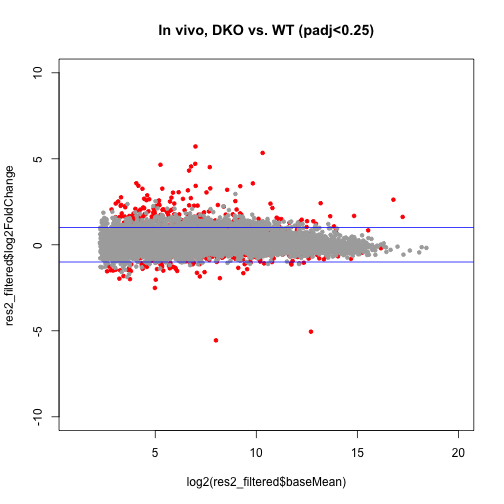

### ApoE vs. DKO

The size of the table with all transcripts is:

```
## [1] 16873    22
```

The size of the table with only significant transcripts ApoE vs. DKO (padj<0.25) is:

```
## [1] 255  22
```

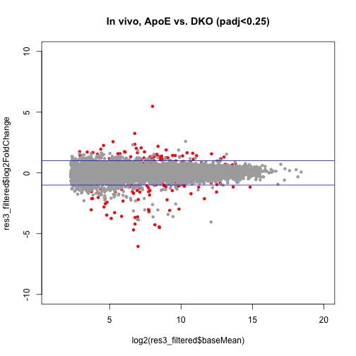

# 4. Venn Diagram

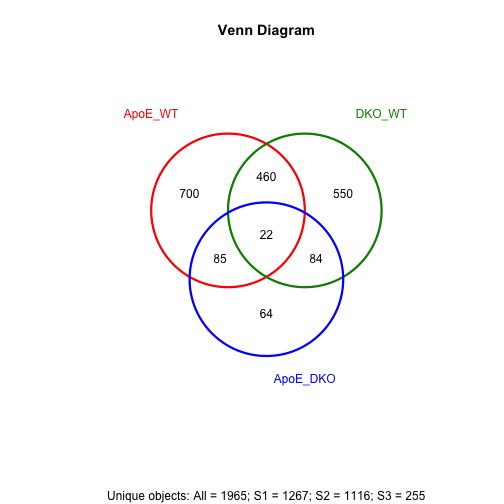

# 5. Heatmap

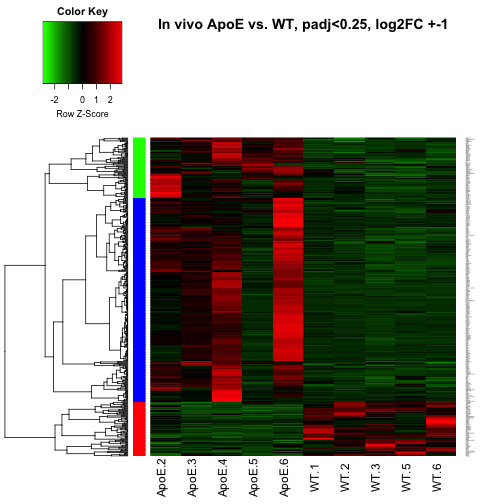

# 6. Comments

The PCA indicates samples are not clearly grouped together by treatment. This could contribute to discrepencies in significant transcripts and could explain why the heatmap does not show clear up- and down-regulated groups of transcripts. Let me know if you would like me to remove any potential outliers from the analysis. Also let me know if you have any questions or would like to change any aspect of the analysis.

# 7. Contact

Lisa Cohen, PhD student in MCIP, UC Davis  
Phone: 321-427-9335  
Email: ljcohen@ucdavis.edu

### Sequencing and original bioinformatics analysis by:

NYU Langone Medical Center  
Bioinformatics Core, Genome Technology Center, OCS  
Email: Genomics@nyumc.org  
Phone: 646-501-2834  
http://ocs.med.nyu.edu/bioinformatics-core  
http://ocs.med.nyu.edu/genome-technology-center

Dr. Steven Shen, Associate Professor  
Email: ShuQuan.Shen@nyumc.org  
Phone: 212-263-2234  
Genome Technology Center, Office of Collaborative Sciences and Center for Health Informatics and Bioinformatics NYU School of Medicine, 227 E30th Street, Room 748, New York, NY 10016

# 8. References

M. I. Love, W. Huber, S. Anders: Moderated estimation of fold change and dispersion for RNA-seq data with DESeq2. Genome Biology 2014, 15:550. http://dx.doi.org/10.1186/s13059-014-0550-8

R-Bioconductor: http://www.bioconductor.org/

DESeq2: http://www.bioconductor.org/packages/release/bioc/vignettes/DESeq2/inst/doc/DESeq2.pdf